# PCIT-CoS-Waitlist RCT Paper 1: DECA Self regulation

Nancy Briggs

### DECA Self regulation

#### Descriptives

| group | time | n | mean | sd | median | min | max |
| --- | --- | --- | --- | --- | --- | --- | --- |
| 1 | 1 | 20 | 39.65000 | 8.021517 | 39.0 | 28 | 53 |
| 1 | 2 | 20 | 41.85000 | 11.338221 | 40.0 | 28 | 70 |
| 1 | 3 | 19 | 40.47368 | 8.643356 | 38.0 | 28 | 55 |
| 2 | 1 | 19 | 36.73684 | 6.427736 | 35.0 | 28 | 53 |
| 2 | 2 | 11 | 37.81818 | 11.504940 | 35.0 | 28 | 61 |
| 2 | 3 | 5 | 35.40000 | 7.056912 | 34.0 | 28 | 45 |
| 3 | 1 | 21 | 43.14286 | 8.162633 | 42.0 | 28 | 58 |
| 3 | 2 | 26 | 39.30769 | 10.563216 | 36.5 | 28 | 61 |
| 3 | 3 | 0 | NaN | NA | NA | Inf | -Inf |

Note this sub scale is only included in the DECA version for children 18 months and older and so there will be missing data/smaller sample size for this analysis

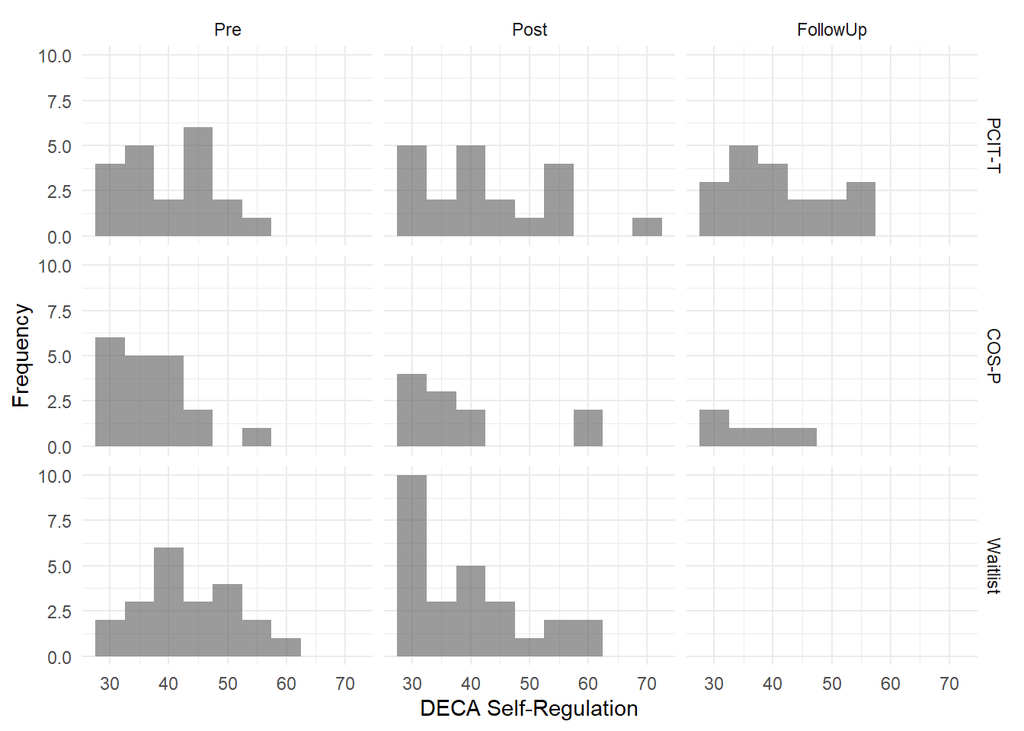

#### Model & Results

A linear mixed model with random effect for individual and fixed effects of group, time and the interaction was run. Estimated marginal means were obtained, and contrasts specified to test Hypothesis 1 and Hypothesis 2.

```
## fixed-effect model matrix is rank deficient so dropping 1 column / coefficient
```

```
## refitting model(s) with ML (instead of REML)
```

|  | Effect | npar | AIC | BIC | logLik | deviance | Chisq | Df | Pr(>Chisq) |
| --- | --- | --- | --- | --- | --- | --- | --- | --- | --- |
| result0 | Intercept | 3 | 1021.670 | 1030.516 | -507.8349 | 1015.670 | NA | NA | NA |
| result1 | Group | 5 | 1023.448 | 1038.192 | -506.7242 | 1013.448 | 2.2213651 | 2 | 0.3293341 |
| result2 | Time | 7 | 1026.941 | 1047.582 | -506.4704 | 1012.941 | 0.5076387 | 2 | 0.7758320 |
| result3 | Group*Time | 10 | 1030.093 | 1059.581 | -505.0467 | 1010.093 | 2.8472413 | 3 | 0.4157821 |

```r
summary(result3)
```

```
## Linear mixed model fit by REML. t-tests use Satterthwaite's method [
## lmerModLmerTest]
## Formula: outcome ~ group * time + (1 | id)
##    Data: dat
##
## REML criterion at convergence: 982.9
##
## Scaled residuals:
##      Min       1Q   Median       3Q      Max
## -1.91196 -0.63435 -0.05456  0.52661  2.97470
##
## Random effects:
##  Groups   Name        Variance Std.Dev.
##  id       (Intercept) 30.29    5.504
##  Residual             55.39    7.442
## Number of obs: 141, groups:  id, 79
##
## Fixed effects:
##              Estimate Std. Error       df t value Pr(>|t|)
## (Intercept)   39.9064     2.0275 130.0844  19.683   <2e-16 ***
## group2        -2.4506     2.9185 128.3284  -0.840    0.403
## group3         2.7992     2.8400 129.4005   0.986    0.326
## time2          1.6328     2.4533  76.1231   0.666    0.508
## time3          0.1192     2.5379  83.8195   0.047    0.963
## group2:time2  -0.9500     3.9640  93.1310  -0.240    0.811
## group3:time2  -5.1995     3.3355  75.2437  -1.559    0.123
## group2:time3  -1.0114     4.9225 101.5357  -0.205    0.838
## ---
## Signif. codes:  0 '***' 0.001 '**' 0.01 '*' 0.05 '.' 0.1 ' ' 1
##
## Correlation of Fixed Effects:
##             (Intr) group2 group3 time2  time3  grp2:2 grp3:2
## group2      -0.695
## group3      -0.714  0.496
## time2       -0.602  0.418  0.430
## time3       -0.605  0.420  0.432  0.526
## group2:tim2  0.373 -0.551 -0.266 -0.619 -0.325
## group3:tim2  0.443 -0.308 -0.622 -0.736 -0.387  0.455
## group2:tim3  0.312 -0.456 -0.223 -0.271 -0.516  0.388  0.199
## fit warnings:
## fixed-effect model matrix is rank deficient so dropping 1 column / coefficient
```

#### Estimated Means & Change

Estimated means for each Treatment and Time are presented. In addition, within-group change between time points is presented with 95% CIs.

##### Group mean difference at each timepoint

Group Differences at Each Time Point

| Group Difference | Time | Mean | SE | t | p | adj p | Lower CL | Upper CL | Effect Size | Lower CL | Upper CL |
| --- | --- | --- | --- | --- | --- | --- | --- | --- | --- | --- | --- |
| 1 - 2 | 1 | 2.451 | 2.927 | 0.837 | 0.681 | 1.000 | -4.489 | 9.390 | 0.336 | 0.573 | 0.573 |
| 1 - 3 | 1 | -2.799 | 2.849 | -0.982 | 0.589 | 0.983 | -9.555 | 3.956 | -0.384 | -0.273 | -0.273 |
| 2 - 3 | 1 | -5.250 | 2.900 | -1.810 | 0.170 | 0.218 | -12.127 | 1.627 | -0.720 | -0.846 | -0.846 |
| 1 - 2 | 2 | 3.401 | 3.406 | 0.998 | 0.579 | 0.960 | -4.674 | 11.475 | 0.466 | 0.487 | 0.487 |
| 1 - 3 | 2 | 2.400 | 2.728 | 0.880 | 0.654 | 1.000 | -4.069 | 8.870 | 0.329 | 0.343 | 0.343 |
| 2 - 3 | 2 | -1.000 | 3.272 | -0.306 | 0.950 | 1.000 | -8.758 | 6.757 | -0.137 | -0.144 | -0.144 |
| 1 - 2 | 3 | 3.462 | 4.471 | 0.774 | 0.719 | 1.000 | -7.137 | 14.061 | 0.475 | 0.484 | 0.484 |
| 1 - 3 | 3 | NA | NA | NA | NA | NA | NA | NA | NA | NA | NA |
| 2 - 3 | 3 | NA | NA | NA | NA | NA | NA | NA | NA | NA | NA |

* Effect size scaled by pooled T1 SD  
† ES 95% Bootstrapped Percentile CI limits  
‡ If you want a positive ES (and it is calculated as negative), be sure to switch the signs and positions of the lower and upper CIs.

##### Change within each group

Within-Group Change and Effect Sizes

| Change | Group | Mean | SE | t | p | adj p | Lower CL | Upper CL | Effect Size | Lower CL | Upper CL |
| --- | --- | --- | --- | --- | --- | --- | --- | --- | --- | --- | --- |
| 1 - 2 | 1 | -1.633 | 2.464 | -0.663 | 0.786 | 1.00 | -7.525 | 4.259 | -0.224 | -0.344 | -0.344 |
| 1 - 3 | 1 | -0.119 | 2.554 | -0.047 | 0.999 | 1.00 | -6.215 | 5.977 | -0.016 | -0.067 | -0.067 |
| 2 - 3 | 1 | 1.514 | 2.438 | 0.621 | 0.809 | 1.00 | -4.330 | 7.357 | 0.208 | 0.277 | 0.277 |
| 1 - 2 | 2 | -0.683 | 3.139 | -0.218 | 0.974 | 1.00 | -8.146 | 6.781 | -0.094 | -0.431 | -0.431 |
| 1 - 3 | 2 | 0.892 | 4.263 | 0.209 | 0.976 | 1.00 | -9.238 | 11.023 | 0.122 | -0.157 | -0.157 |
| 2 - 3 | 2 | 1.575 | 4.379 | 0.360 | 0.931 | 1.00 | -8.861 | 12.011 | 0.216 | 0.274 | 0.274 |
| 1 - 2 | 3 | 3.567 | 2.268 | 1.573 | 0.264 | 0.36 | -1.859 | 8.992 | 0.489 | 0.272 | 0.272 |
| 1 - 3 | 3 | NA | NA | NA | NA | NA | NA | NA | NA | NA | NA |
| 2 - 3 | 3 | NA | NA | NA | NA | NA | NA | NA | NA | NA | NA |

* Effect size scaled by pooled T1 SD  
† ES 95% Bootstrapped Percentile CI limits  
‡ If you want a positive ES (and it is calculated as negative), be sure to switch the signs and positions of the lower and upper CIs.

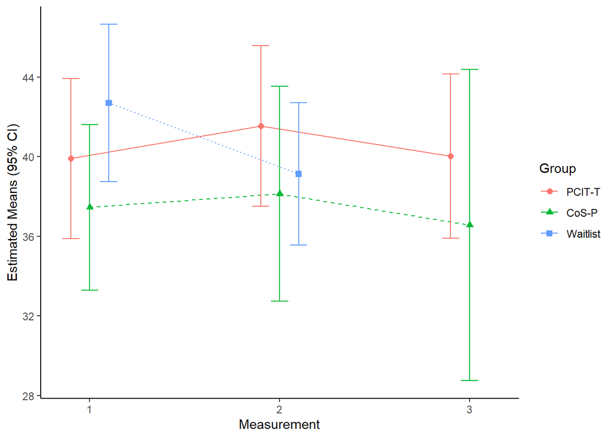

#### Hypothesis 1

We hypothesize that from baseline (‘T1’) to post-treatment/waitlist (‘T2’) there will be a gradient effect, whereby parent-child dyads who receive PCIT-T will show the greatest gains and parent-child dyads who receive no treatment will show the least gains. For the outcome, then, the null hypothesis is:

$H_0: \text {mean change}(\text{PCIT-T}) = \text {mean change}(\text{CoS-P}) = \text {mean change}(\text{Waitlist})$ $H_A: \text {mean change}(\text{PCIT-T}) > \text {mean change}(\text{CoS-P}) > \text {mean change}(\text{Waitlist})$

This is a joint hypothesis test.

First, confirming that the ordering of the means is as hypothesized:

```
## group = 1:
##  contrast estimate   SE    df t.ratio p.value
##  1 - 2      -1.633 2.46  75.1  -0.663  0.7858
##  1 - 3      -0.119 2.55  82.9  -0.047  0.9988
##  2 - 3       1.514 2.44  67.0   0.621  0.8092
##
## group = 2:
##  contrast estimate   SE    df t.ratio p.value
##  1 - 2      -0.683 3.14 103.7  -0.218  0.9743
##  1 - 3       0.892 4.26 107.4   0.209  0.9761
##  2 - 3       1.575 4.38  89.2   0.360  0.9312
##
## group = 3:
##  contrast estimate   SE    df t.ratio p.value
##  1 - 2       3.567 2.27  73.2   1.573  0.2639
##  1 - 3      nonEst   NA    NA      NA      NA
##  2 - 3      nonEst   NA    NA      NA      NA
##
## Degrees-of-freedom method: kenward-roger
## P value adjustment: tukey method for comparing a family of 3 estimates
```

Now, to get the p-value associated with the joint hypothesis.

```
##   (Intercept) group2 group3 time2 time3 group2:time2 group3:time2 group2:time3
## 1           0      0      0     0     0           -1            0            0
## 2           0      0      0     0     1            0            1            0
```

```
##
##   General Linear Hypotheses
##
## Linear Hypotheses:
##        Estimate
## 1 == 0     0.95
## 2 == 0    -5.08
##
## Global Test:
##       F DF1 DF2 Pr(>F)
## 1 1.174   2 131 0.3123
```

p>0.05

#### Hypothesis 2

##### Change from T2-T3

There will be a gradient of size of change from T2 to T3 such that the change in the PCIT-T group > the change in the CoS-P group. This isn’t really a gradient; it’s just 1 hypothesis.

First, the change in PCITT and COSP from time 2 to time 3:

```
## group = 1:
##  time emmean   SE  df lower.CL upper.CL
##  1      39.9 2.03 130     35.9     43.9
##  2      41.5 2.04 129     37.5     45.6
##  3      40.0 2.09 130     35.9     44.2
##
## group = 2:
##  time emmean   SE  df lower.CL upper.CL
##  1      37.5 2.10 126     33.3     41.6
##  2      38.1 2.73 133     32.7     43.5
##  3      36.6 3.95 126     28.7     44.4
##
## group = 3:
##  time emmean   SE  df lower.CL upper.CL
##  1      42.7 2.00 128     38.8     46.7
##  2      39.1 1.81 122     35.6     42.7
##  3    nonEst   NA  NA       NA       NA
##
## Degrees-of-freedom method: kenward-roger
## Confidence level used: 0.95
```

```
## group = 1:
##  contrast estimate   SE    df lower.CL upper.CL
##  1 - 2      -1.633 2.46  75.1    -7.52     4.26
##  1 - 3      -0.119 2.55  82.9    -6.22     5.98
##  2 - 3       1.514 2.44  67.0    -4.33     7.36
##
## group = 2:
##  contrast estimate   SE    df lower.CL upper.CL
##  1 - 2      -0.683 3.14 103.7    -8.15     6.78
##  1 - 3       0.892 4.26 107.4    -9.24    11.02
##  2 - 3       1.575 4.38  89.2    -8.86    12.01
##
## group = 3:
##  contrast estimate   SE    df lower.CL upper.CL
##  1 - 2       3.567 2.27  73.2    -1.86     8.99
##  1 - 3      nonEst   NA    NA       NA       NA
##  2 - 3      nonEst   NA    NA       NA       NA
##
## Degrees-of-freedom method: kenward-roger
## Confidence level used: 0.95
## Conf-level adjustment: tukey method for comparing a family of 3 estimates
```

```r
## Specify contrast matrices
# Hyp1 is 1 df test
# could use alternative="less" ir alternative="greater" in glht
hyp2   <- matrix(c(0, 0,0, 0,0, -1,0,1 ),1)
hyp2F <- glht(result3, linfct = hyp2)
summary(hyp2F)
```

```
##
##   Simultaneous Tests for General Linear Hypotheses
##
## Fit: lmer(formula = outcome ~ group * time + (1 | id), data = dat)
##
## Linear Hypotheses:
##        Estimate Std. Error z value Pr(>|z|)
## 1 == 0 -0.06138    4.97895  -0.012     0.99
## (Adjusted p values reported -- single-step method)
```

```r
s<-summary(hyp2F, test = Ftest())
#also see this webpage for more on contrasts https://rcompanion.org/rcompanion/h_01.html



## Extract pvaue for evidence / no evidence
evidence = ifelse(s$test$pvalue<0.05, "evidence", "no evidence")
```

Change in G1 from T2 to T3: 1.514

Change in G2 from T2 to T3: 1.575

##### Change from T1-T3

```
##
##   General Linear Hypotheses
##
## Linear Hypotheses:
##        Estimate
## 1 == 0   -1.011
##
## Global Test:
##         F DF1 DF2 Pr(>F)
## 1 0.04222   1 131 0.8375
```

Change in G1 from T1 to T3: -0.119

Change in G2 from T1 to T3: 0.892

p=0.8375. We have no evidence that the change from T1 to T3 is different for G1 and G2

#### Residuals

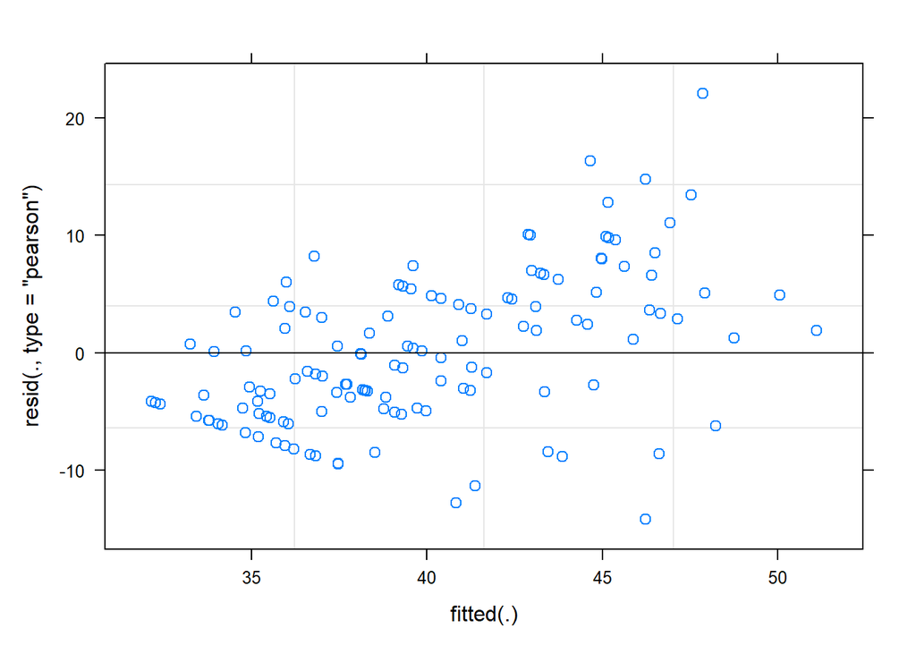

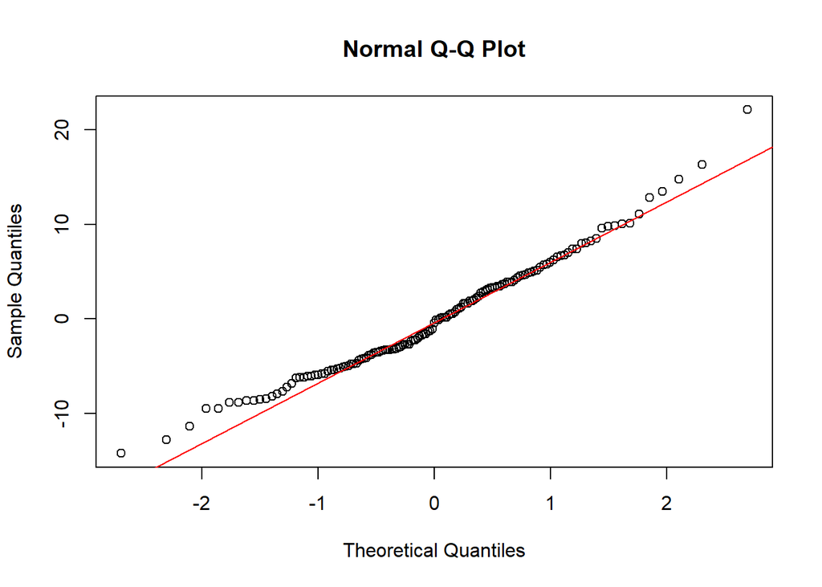

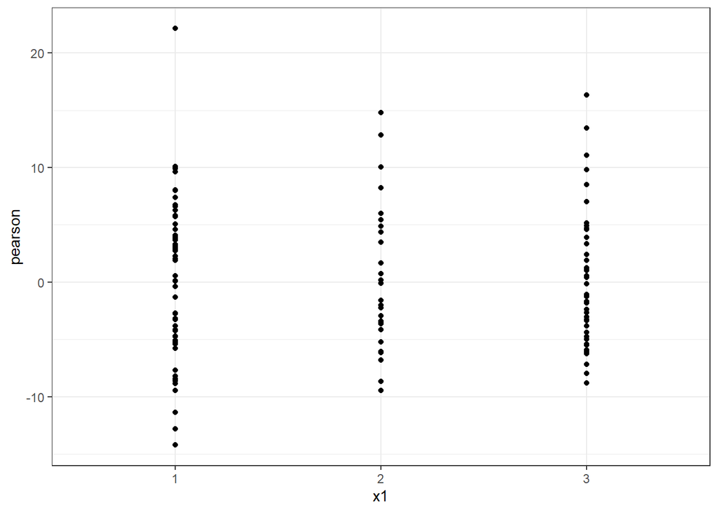

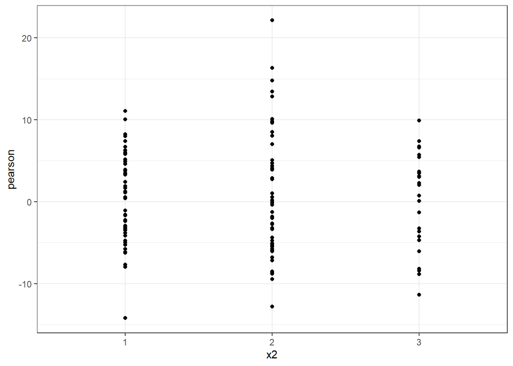

```r
rm(list = ls())
```